# Bayesian GLMM Part3

```r
starling_brm4 |> get_variables()
```

```
  [1] "b_Intercept"                   "b_MONTHJan"
  [3] "b_SITUATIONnestMbox"           "b_SITUATIONother"
  [5] "b_SITUATIONtree"               "b_MONTHJan:SITUATIONnestMbox"
  [7] "b_MONTHJan:SITUATIONother"     "b_MONTHJan:SITUATIONtree"
  [9] "sd_BIRD__Intercept"            "sd_BIRD__MONTHJan"
 [11] "cor_BIRD__Intercept__MONTHJan" "sigma"
 [13] "Intercept"                     "r_BIRD[inside1,Intercept]"
 [15] "r_BIRD[inside10,Intercept]"    "r_BIRD[inside2,Intercept]"
 [17] "r_BIRD[inside3,Intercept]"     "r_BIRD[inside4,Intercept]"
 [19] "r_BIRD[inside5,Intercept]"     "r_BIRD[inside6,Intercept]"
 [21] "r_BIRD[inside7,Intercept]"     "r_BIRD[inside8,Intercept]"
 [23] "r_BIRD[inside9,Intercept]"     "r_BIRD[nest-box1,Intercept]"
 [25] "r_BIRD[nest-box10,Intercept]"  "r_BIRD[nest-box2,Intercept]"
 [27] "r_BIRD[nest-box3,Intercept]"   "r_BIRD[nest-box4,Intercept]"
 [29] "r_BIRD[nest-box5,Intercept]"   "r_BIRD[nest-box6,Intercept]"
```

[output cut: 38 more lines]

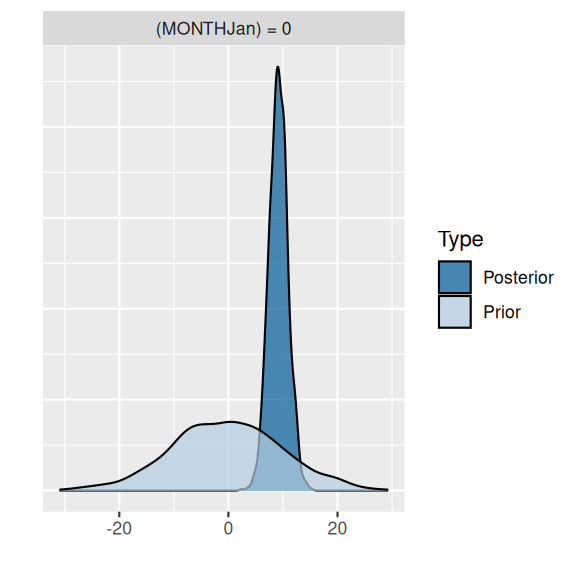

```r
starling_brm4 |>
  hypothesis("MONTHJan=0") |>
  plot()
```

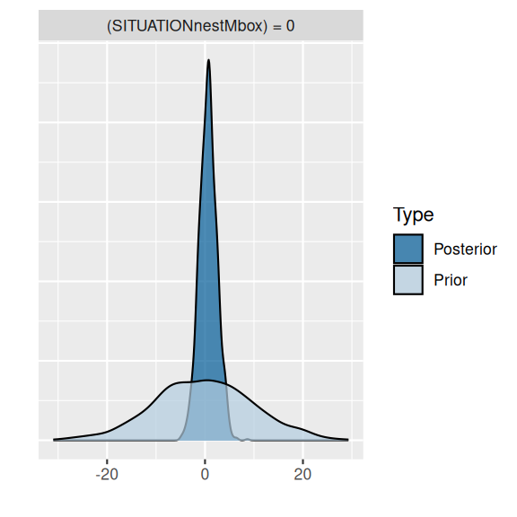

```r
starling_brm4 |>
  hypothesis("SITUATIONnestMbox=0") |>
  plot()
```

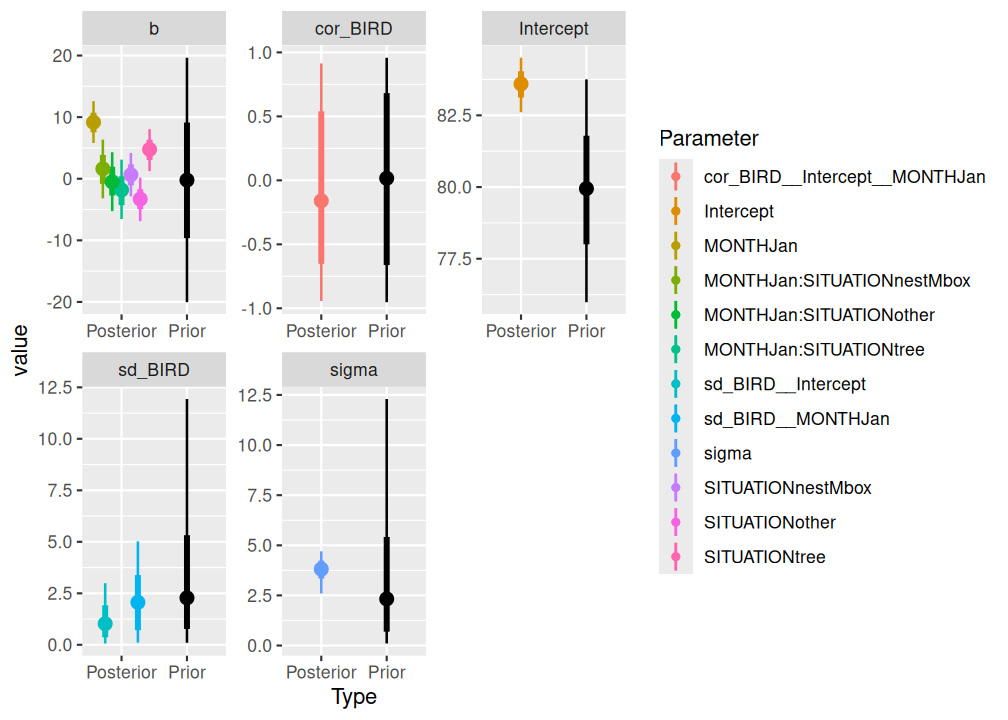

```r
starling_brm4 |> SUYR_prior_and_posterior()
```

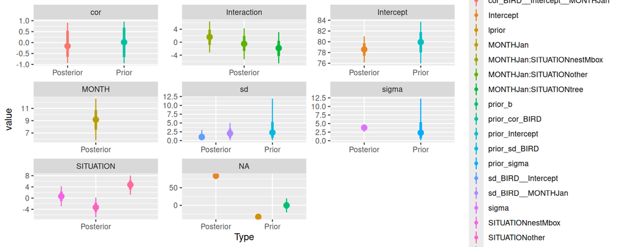

```r
starling_brm4 |>
  posterior_samples() |>
  dplyr::select(-`lp__`) |>
  pivot_longer(everything(), names_to = "key") |>
  filter(!str_detect(key, "^r")) |>
  mutate(
    Type = ifelse(str_detect(key, "prior"), "Prior", "Posterior"),
    ## Class = ifelse(str_detect(key, 'Intercept'),  'Intercept',
    ##         ifelse(str_detect(key, 'b'),  'b', 'sigma')),
    Class = case_when(
      str_detect(key, "(^b|^prior).*Intercept$") ~ "Intercept",
      str_detect(key, "b_SITUATION.*|prior_b_SITUATION.*") &
        !str_detect(key, ".*:.*") ~ "SITUATION",
      str_detect(key, "b_MONTH.*|prior_b_MONTH.*") &
        !str_detect(key, ".*\\:.*") ~ "MONTH",
      str_detect(key, ".*\\:.*|prior_b_.*\\:.*") ~ "Interaction",
      str_detect(key, "sd") ~ "sd",
      str_detect(key, "^cor|prior_cor") ~ "cor",
      str_detect(key, "sigma") ~ "sigma"
    ),
    Par = str_replace(key, "b_", "")
  ) |>
  ggplot(aes(x = Type, y = value, color = Par)) +
  stat_pointinterval(position = position_dodge()) +
  facet_wrap(~Class, scales = "free")
```

**Compare models**

We can compare the two models using LOO

```r
(l.1 <- starling_brm3 |> rstan::loo())
```

```
Computed from 2400 by 80 log-likelihood matrix.

         Estimate   SE
elpd_loo   -233.9  5.1
p_loo        13.3  1.5
looic       467.8 10.2
------
MCSE of elpd_loo is 0.1.
MCSE and ESS estimates assume MCMC draws (r_eff in [0.7, 1.1]).

All Pareto k estimates are good (k < 0.7).
See help('pareto-k-diagnostic') for details.
```

```r
(l.2 <- starling_brm4 |> rstan::loo())
```

```
Computed from 1500 by 80 log-likelihood matrix.

         Estimate   SE
elpd_loo   -232.0  5.0
p_loo        22.5  2.3
looic       464.1 10.1
------
MCSE of elpd_loo is NA.
MCSE and ESS estimates assume MCMC draws (r_eff in [0.2, 0.9]).

Pareto k diagnostic values:
                          Count Pct.    Min. ESS
(-Inf, 0.69]   (good)     78    97.5%   77
   (0.69, 1]   (bad)       2     2.5%   <NA>
    (1, Inf)   (very bad)  0     0.0%   <NA>
See help('pareto-k-diagnostic') for details.
```

```r
loo_compare(l.1, l.2)
```

```
              elpd_diff se_diff
starling_brm4  0.0       0.0
starling_brm3 -1.8       0.8
```

There is only slightly more support for the more complex random intercept/slope model over the simpler random intercept only model. Consequently, we could argue in favour of either. Since we have already fit the random intercept/slope model, we will use that one.

# 6 MCMC sampling diagnostics

**brms**

**bayesplot**

The `bayesplot` package offers a range of MCMC diagnostics as well as Posterior Probability Checks (PPC), all of which have a convenient `plot()` interface. Lets start with the MCMC diagnostics.

**See list of available diagnostics by name**

```r
available_mcmc()
```

```
bayesplot MCMC module:
  mcmc_acf
  mcmc_acf_bar
  mcmc_areas
  mcmc_areas_ridges
  mcmc_combo
  mcmc_dens
  mcmc_dens_chains
  mcmc_dens_overlay
  mcmc_hex
  mcmc_hist
  mcmc_hist_by_chain
  mcmc_intervals
  mcmc_neff
  mcmc_neff_hist
  mcmc_nuts_acceptance
  mcmc_nuts_divergence
  mcmc_nuts_energy
  mcmc_nuts_stepsize
  mcmc_nuts_treedepth
  mcmc_pairs
  mcmc_parcoord
  mcmc_rank_ecdf
  mcmc_rank_hist
  mcmc_rank_overlay
  mcmc_recover_hist
  mcmc_recover_intervals
  mcmc_recover_scatter
  mcmc_rhat
  mcmc_rhat_hist
  mcmc_scatter
  mcmc_trace
  mcmc_trace_highlight
  mcmc_violin
```

Of these, we will focus on:

- trace: this plots the estimates of each parameter over the post-warmup length of each MCMC chain. Each chain is plotted in a different shade of blue, with each parameter in its own facet. Ideally, each **trace** should just look like noise without any discernible drift and each of the traces for a specific parameter should look the same (i.e, should not be displaced above or below any other trace for that parameter).

```r
pars <- starling_brm4 |> get_variables()
pars <- pars |>
  str_extract("^b_.*|[sS]igma|^sd.*") |>
  ## str_extract('^b.Intercept|^b_SITUTATION.*|^b_MONTH.*|[sS]igma|^sd.*') |>
  na.omit()
pars
```

```
 [1] "b_Intercept"                  "b_MONTHJan"
 [3] "b_SITUATIONnestMbox"          "b_SITUATIONother"
 [5] "b_SITUATIONtree"              "b_MONTHJan:SITUATIONnestMbox"
 [7] "b_MONTHJan:SITUATIONother"    "b_MONTHJan:SITUATIONtree"
 [9] "sd_BIRD__Intercept"           "sd_BIRD__MONTHJan"
[11] "sigma"                        "sigma"
attr(,"na.action")
 [1]  11  13  14  15  16  17  18  19  20  21  22  23  24  25  26  27  28  29  30
[20]  31  32  33  34  35  36  37  38  39  40  41  42  43  44  45  46  47  48  49
[39]  50  51  52  53  54  55  56  57  58  59  60  61  62  63  64  65  66  67  68
[58]  69  70  71  72  73  74  75  76  77  78  79  80  81  82  83  84  85  86  87
[77]  88  89  90  91  92  93  94  95  97  98  99 100 101 102 103 104 105 106
attr(,"class")
[1] "omit"
```

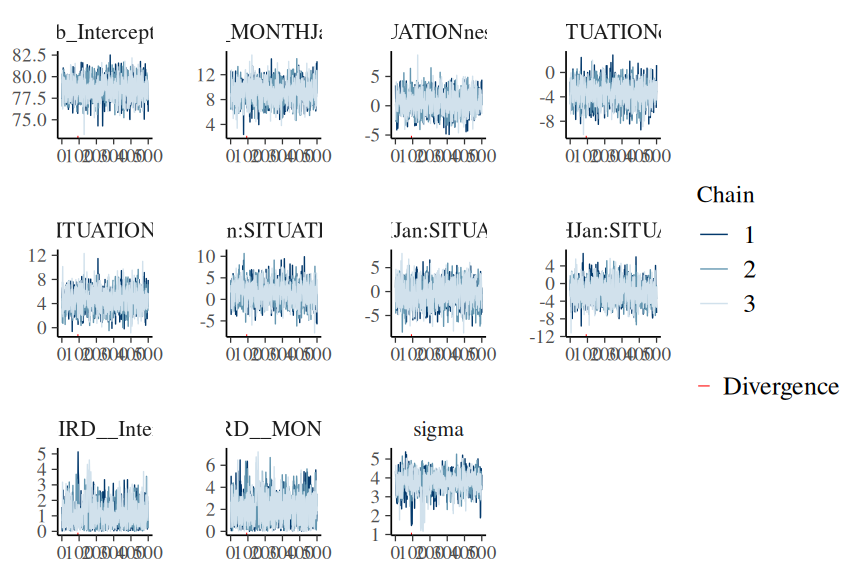

```r
starling_brm4 |> mcmc_plot(type = "trace", variable = pars)
```

The chains appear well mixed and very similar

- acf_bar (autocorrelation function): plots the autocorrelation between successive MCMC sample lags for each parameter and each chain

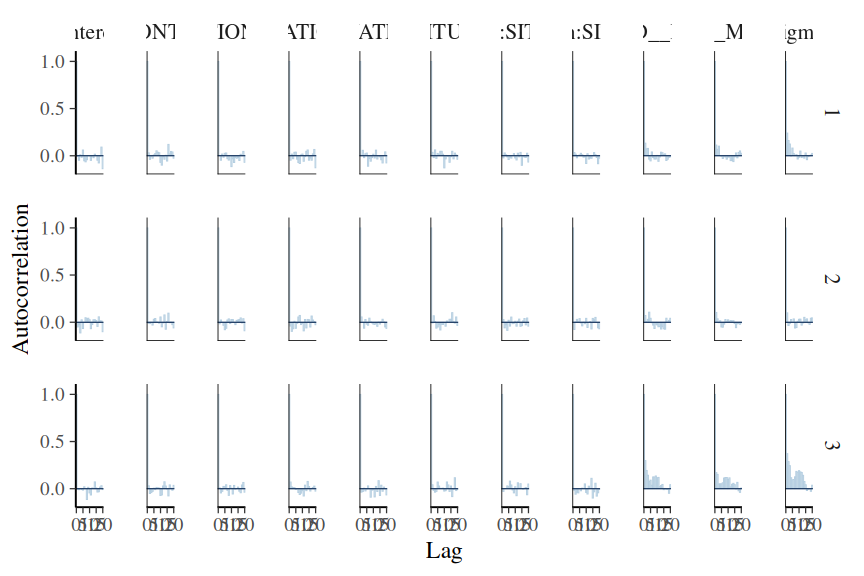

```r
starling_brm4 |> mcmc_plot(type = "acf_bar", variable = pars)
```

There is no evidence of auto-correlation in the MCMC samples

- rhat_hist: Rhat is a **scale reduction factor** measure of convergence between the chains. The closer the values are to 1, the more the chains have converged. Values greater than 1.05 indicate a lack of convergence. There will be an Rhat value for each parameter estimated.

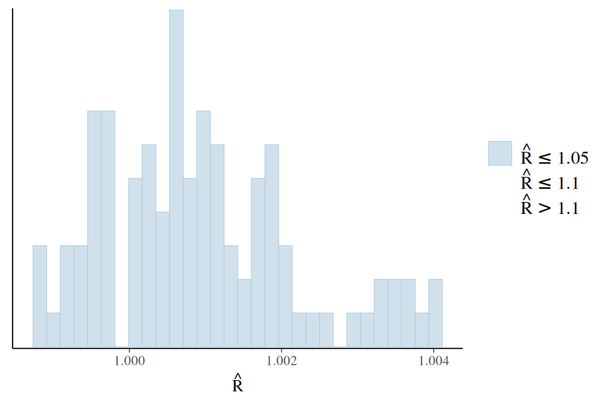

```r
starling_brm4 |> mcmc_plot(type = "rhat_hist")
```

All Rhat values are below 1.05, suggesting the chains have converged.

- neff_hist (number of effective samples): the ratio of the number of effective samples (those not rejected by the sampler) to the number of samples provides an indication of the effectiveness (and efficiency) of the MCMC sampler. Ratios that are less than 0.5 for a parameter suggest that the sampler spent considerable time in difficult areas of the sampling domain and rejected more than half of the samples (replacing them with the previous effective sample).

  If the ratios are low, tightening the priors may help.

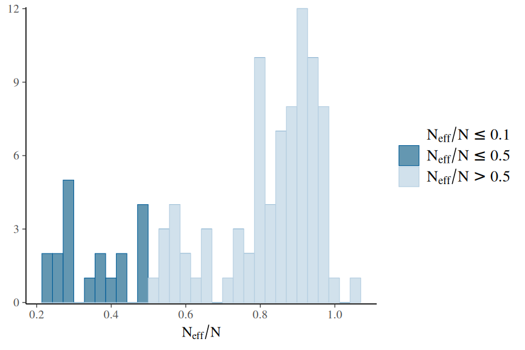

```r
starling_brm4 |> mcmc_plot(type = "neff_hist")
```

**More diagnostics**

[figure not shown]

```r
starling_brm4 |> mcmc_plot(type = "combo", variable = pars)
```

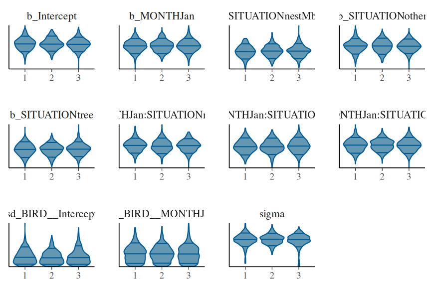

```r
starling_brm4 |> mcmc_plot(type = "violin", variable = pars)
```

**stan plots**

The `rstan` package offers a range of MCMC diagnostics. Lets start with the MCMC diagnostics.

Of these, we will focus on:

- stan_trace: this plots the estimates of each parameter over the post-warmup length of each MCMC chain. Each chain is plotted in a different colour, with each parameter in its own facet. Ideally, each **trace** should just look like noise without any discernible drift and each of the traces for a specific parameter should look the same (i.e, should not be displaced above or below any other trace for that parameter).

```r
starling_brm4 |> get_variables()
```

```
  [1] "b_Intercept"                   "b_MONTHJan"
  [3] "b_SITUATIONnestMbox"           "b_SITUATIONother"
  [5] "b_SITUATIONtree"               "b_MONTHJan:SITUATIONnestMbox"
  [7] "b_MONTHJan:SITUATIONother"     "b_MONTHJan:SITUATIONtree"
  [9] "sd_BIRD__Intercept"            "sd_BIRD__MONTHJan"
 [11] "cor_BIRD__Intercept__MONTHJan" "sigma"
 [13] "Intercept"                     "r_BIRD[inside1,Intercept]"
 [15] "r_BIRD[inside10,Intercept]"    "r_BIRD[inside2,Intercept]"
 [17] "r_BIRD[inside3,Intercept]"     "r_BIRD[inside4,Intercept]"
 [19] "r_BIRD[inside5,Intercept]"     "r_BIRD[inside6,Intercept]"
 [21] "r_BIRD[inside7,Intercept]"     "r_BIRD[inside8,Intercept]"
 [23] "r_BIRD[inside9,Intercept]"     "r_BIRD[nest-box1,Intercept]"
 [25] "r_BIRD[nest-box10,Intercept]"  "r_BIRD[nest-box2,Intercept]"
 [27] "r_BIRD[nest-box3,Intercept]"   "r_BIRD[nest-box4,Intercept]"
 [29] "r_BIRD[nest-box5,Intercept]"   "r_BIRD[nest-box6,Intercept]"
```

[output cut: 38 more lines]

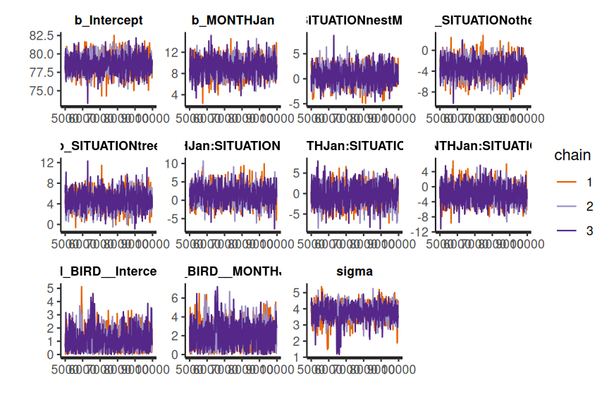

```r
pars <- starling_brm4 |> get_variables()
pars <- str_extract(pars, "^b_.*|^sigma$|^sd.*") |> na.omit()

starling_brm4$fit |>
  stan_trace(pars = pars)
```

The chains appear well mixed and very similar

- stan_acf (auto-correlation function): plots the auto-correlation between successive MCMC sample lags for each parameter and each chain

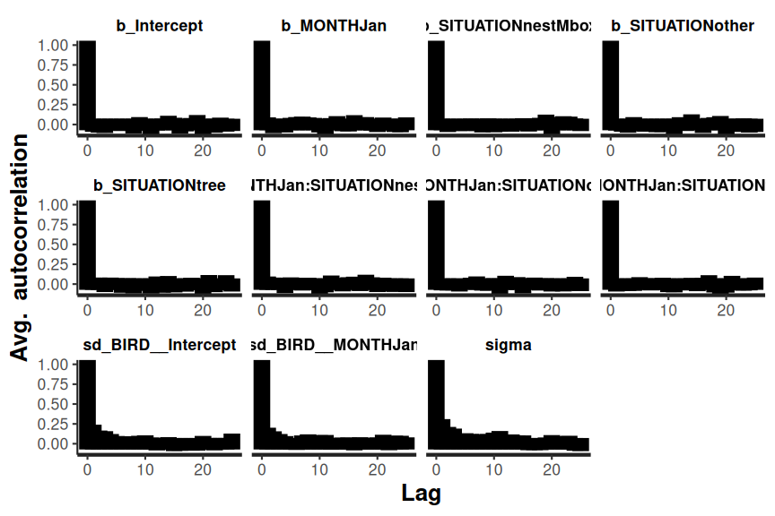

```r
starling_brm4$fit |>
  stan_ac(pars = pars)
```

There is no evidence of auto-correlation in the MCMC samples

- stan_rhat: Rhat is a **scale reduction factor** measure of convergence between the chains. The closer the values are to 1, the more the chains have converged. Values greater than 1.05 indicate a lack of convergence. There will be an Rhat value for each parameter estimated.

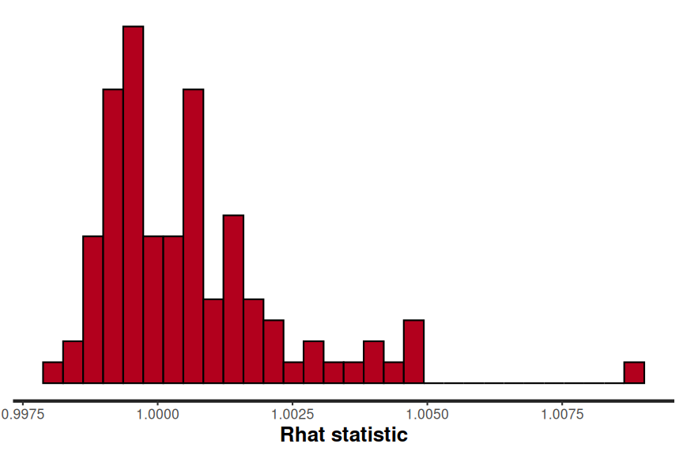

```r
starling_brm4$fit |> stan_rhat()
```

All Rhat values are below 1.05, suggesting the chains have converged.

- stan_ess (number of effective samples): the ratio of the number of effective samples (those not rejected by the sampler) to the number of samples provides an indication of the effectiveness (and efficiency) of the MCMC sampler. Ratios that are less than 0.5 for a parameter suggest that the sampler spent considerable time in difficult areas of the sampling domain and rejected more than half of the samples (replacing them with the previous effective sample).

  If the ratios are low, tightening the priors may help.

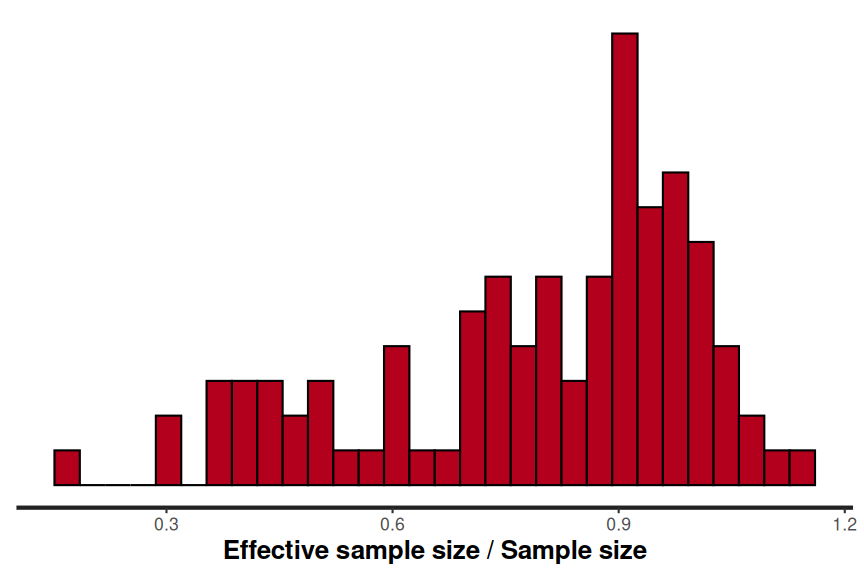

```r
starling_brm4$fit |> stan_ess()
```

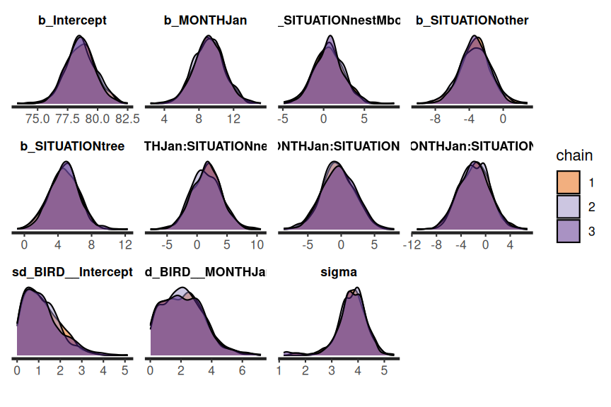

```r
starling_brm4$fit |>
  stan_dens(separate_chains = TRUE, pars = pars)
```

**ggmcmc**

The `ggmean` package also as a set of MCMC diagnostic functions. Lets start with the MCMC diagnostics.

Of these, we will focus on:

- ggs_traceplot: this plots the estimates of each parameter over the post-warmup length of each MCMC chain. Each chain is plotted in a different colour, with each parameter in its own facet. Ideally, each **trace** should just look like noise without any discernible drift and each of the traces for a specific parameter should look the same (i.e, should not be displaced above or below any other trace for that parameter).

```r
## starling_ggs <- starling_brm3 %>% ggs(burnin = FALSE, inc_warmup = FALSE)
## starling_ggs %>% ggs_traceplot()
```

- gss_autocorrelation (autocorrelation function): plots the autocorrelation between successive MCMC sample lags for each parameter and each chain

```r
## ggs_autocorrelation(starling_ggs)
```

- stan_rhat: Rhat is a **scale reduction factor** measure of convergence between the chains. The closer the values are to 1, the more the chains have converged. Values greater than 1.05 indicate a lack of convergence. There will be an Rhat value for each parameter estimated.

```r
## ggs_Rhat(starling_ggs)
```

- stan_ess (number of effective samples): the ratio of the number of effective samples (those not rejected by the sampler) to the number of samples provides an indication of the effectiveness (and efficiency) of the MCMC sampler. Ratios that are less than 0.5 for a parameter suggest that the sampler spent considerable time in difficult areas of the sampling domain and rejected more than half of the samples (replacing them with the previous effective sample).

  If the ratios are low, tightening the priors may help.

```r
## ggs_effective(starling_ggs)
```

**More diagnostics**

```r
## ggs_crosscorrelation(starling_ggs)
```

```r
## ggs_grb(starling_ggs)
```

# 7 Model validation

**brms**

**pp check**

Post predictive checks provide additional diagnostics about the fit of the model. Specifically, they provide a comparison between predictions drawn from the model and the observed data used to train the model.

**See list of available diagnostics by name**

```r
available_ppc()
```

```
bayesplot PPC module:
  ppc_bars
  ppc_bars_grouped
  ppc_boxplot
  ppc_dens
  ppc_dens_overlay
  ppc_dens_overlay_grouped
  ppc_dots
  ppc_ecdf_overlay
  ppc_ecdf_overlay_grouped
  ppc_error_binned
  ppc_error_hist
  ppc_error_hist_grouped
  ppc_error_scatter
  ppc_error_scatter_avg
  ppc_error_scatter_avg_grouped
  ppc_error_scatter_avg_vs_x
  ppc_freqpoly
  ppc_freqpoly_grouped
  ppc_hist
  ppc_intervals
  ppc_intervals_grouped
  ppc_km_overlay
  ppc_km_overlay_grouped
  ppc_loo_intervals
  ppc_loo_pit_ecdf
  ppc_loo_pit_overlay
  ppc_loo_pit_qq
  ppc_loo_ribbon
  ppc_pit_ecdf
  ppc_pit_ecdf_grouped
  ppc_ribbon
  ppc_ribbon_grouped
  ppc_rootogram
  ppc_scatter
  ppc_scatter_avg
  ppc_scatter_avg_grouped
  ppc_stat
  ppc_stat_2d
  ppc_stat_freqpoly
  ppc_stat_freqpoly_grouped
  ppc_stat_grouped
  ppc_violin_grouped
```

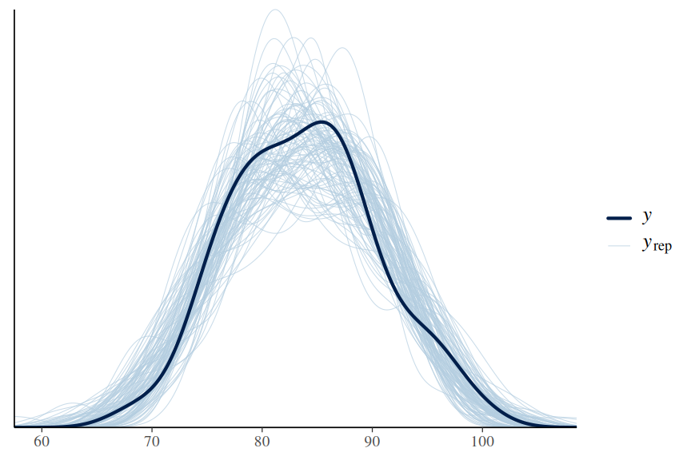

```r
starling_brm4 |> pp_check(type = "dens_overlay", nsamples = 100)
```

The model draws appear to be consistent with the observed data.

- error_scatter_avg: this plots the observed values against the average residuals. Similar to a residual plot, we do not want to see any patterns in this plot. Note, this is not really that useful for models that involve a binomial response

```r
## starling_brm4 |> pp_check(type = 'error_scatter_avg')
```

This is not really interpretable

- intervals: plots the observed data overlayed on top of posterior predictions associated with each level of the predictor. Ideally, the observed data should all fall within the predictive intervals.

```
Using all posterior draws for ppc type 'intervals' by default.
```

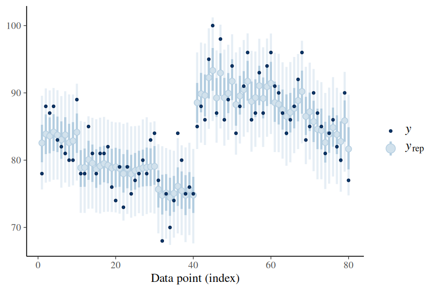

```r
starling_brm4 |> pp_check(group = "BIRD", type = "intervals")
```

The `shinystan` package allows the full suite of MCMC diagnostics and posterior predictive checks to be accessed via a web interface.

```r
# library(shinystan)
# launch_shinystan(starling_brm2)
```

**DHARMa residuals**

DHARMa residuals provide very useful diagnostics. Unfortunately, we cannot directly use the `simulateResiduals()` function to generate the simulated residuals. However, if we are willing to calculate some of the components yourself, we can still obtain the simulated residuals from the fitted stan model.

We need to supply:

- simulated (predicted) responses associated with each observation.
- observed values
- fitted (predicted) responses (averaged) associated with each observation

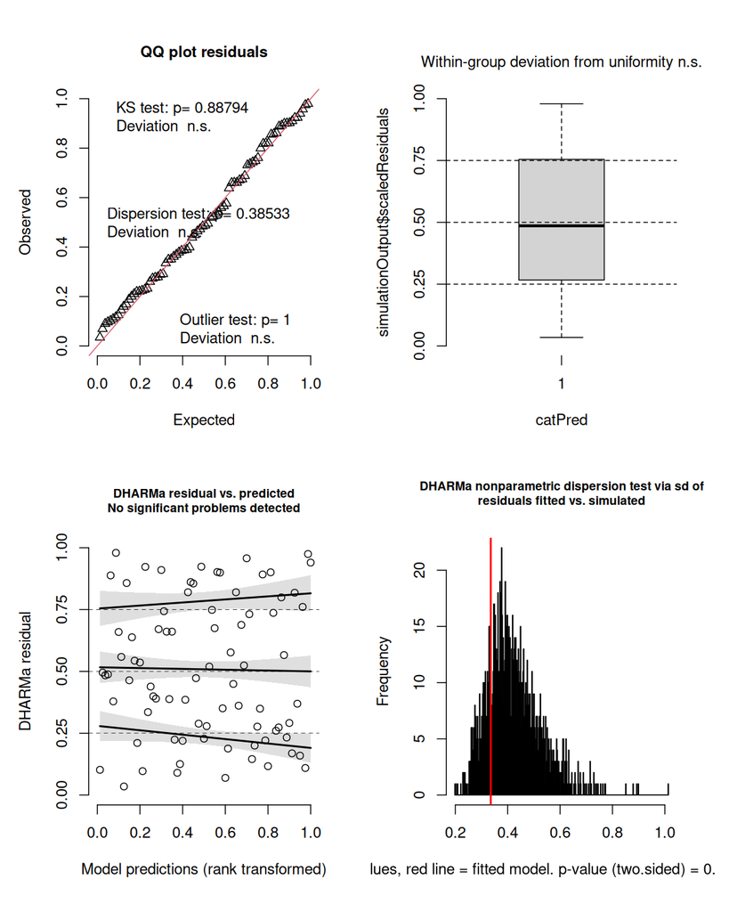

```r
starling_resids <- make_brms_dharma_res(starling_brm4, integerResponse = FALSE)
wrap_elements(~ testUniformity(starling_resids)) +
  wrap_elements(~ plotResiduals(starling_resids, form = factor(rep(1, nrow(starling))))) +
  wrap_elements(~ plotResiduals(starling_resids, quantreg = TRUE)) +
  wrap_elements(~ testDispersion(starling_resids))
```

**Conclusions:**

- the simulated residuals do not suggest any issues with the residuals
- there is no evidence of a lack of fit.

# 8 Partial effects plots

**brms**

**conditional_effects**

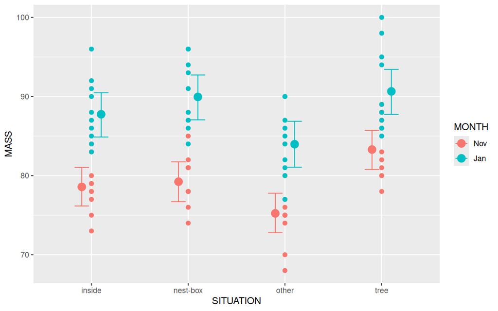

```r
starling_brm4 |>
  conditional_effects("SITUATION:MONTH") |>
  plot(points = TRUE)
```

**ggpredict**

```
Note: uncertainty of error terms are not taken into account. Consider
  setting `interval` to "prediction". This will call `posterior_predict()`
  instead of `posterior_epred()`.
```

```
Data points may overlap. Use the `jitter` argument to add some amount of
  random variation to the location of data points and avoid overplotting.
```

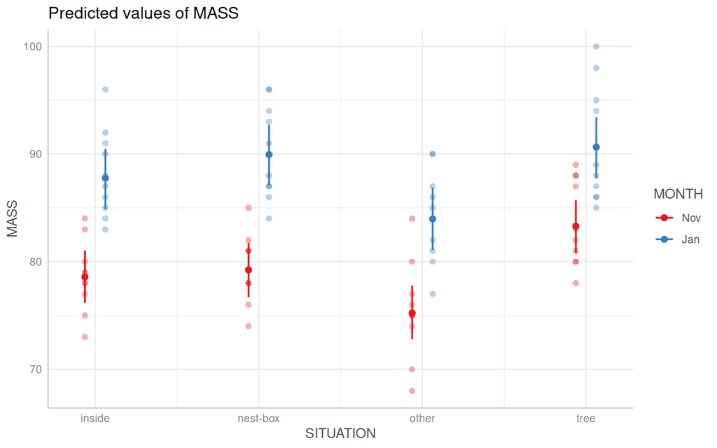

```r
starling_brm4 |>
  ggpredict(~ SITUATION * MONTH) |>
  plot(show_data = TRUE)
```

**ggemmeans**

```
Data points may overlap. Use the `jitter` argument to add some amount of
  random variation to the location of data points and avoid overplotting.
```

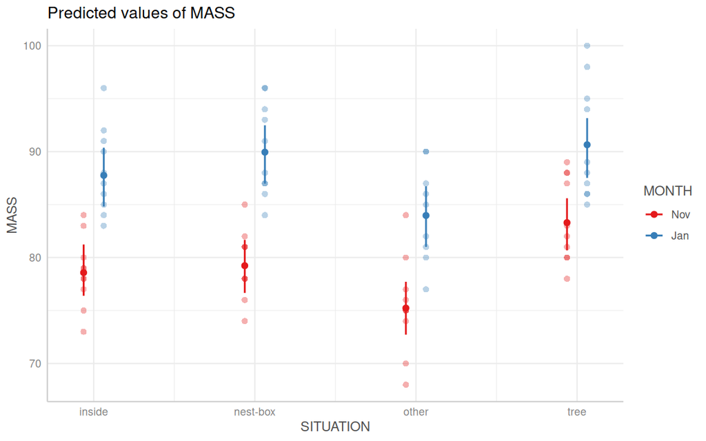

```r
starling_brm4 |>
  ggemmeans(~ SITUATION * MONTH) |>
  plot(show_data = TRUE)
```

**fitted_draws**

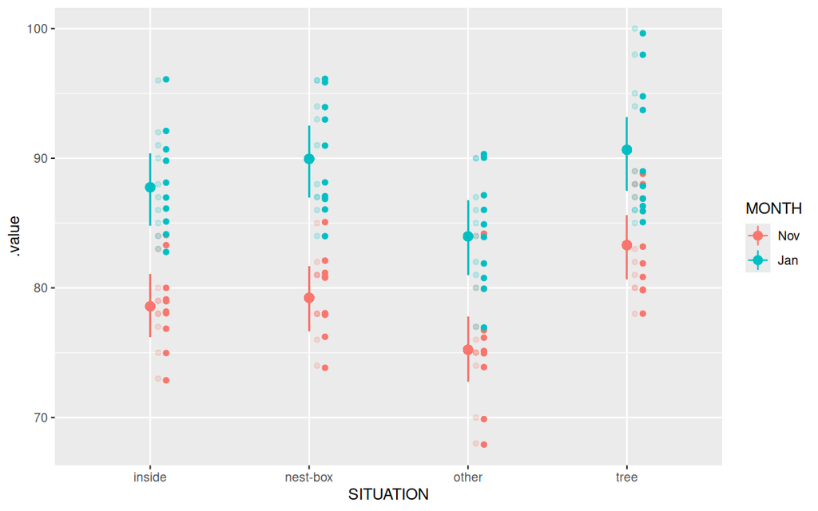

```r
Partial.obs <- starling_brm4$data |>
  mutate(
    Pred = predict(starling_brm4)[, "Estimate"],
    Resid = resid(starling_brm4)[, "Estimate"],
    Obs = Pred + Resid
  )

starling_brm4 |>
  fitted_draws(newdata = starling, re_formula = NA) |>
  median_hdci() |>
  ggplot(aes(x = SITUATION, y = .value, color = MONTH)) +
  geom_pointrange(aes(ymin = .lower, ymax = .upper)) +
  geom_line() +
  geom_point(
    data = Partial.obs, aes(y = Obs, x = SITUATION, color = MONTH),
    position = position_nudge(x = 0.1)
  ) +
  geom_point(
    data = starling, aes(y = MASS, x = SITUATION, color = MONTH), alpha = 0.2,
    position = position_nudge(x = 0.05)
  )
```

# 9 Model investigation

**brms**

**summary**

```r
starling_brm4 |> summary()
```

```
 Family: gaussian
  Links: mu = identity; sigma = identity
Formula: MASS ~ MONTH * SITUATION + (MONTH | BIRD)
   Data: starling (Number of observations: 80)
  Draws: 3 chains, each with iter = 10000; warmup = 5000; thin = 10;
         total post-warmup draws = 1500

Multilevel Hyperparameters:
~BIRD (Number of levels: 40)
                        Estimate Est.Error l-95% CI u-95% CI Rhat Bulk_ESS
sd(Intercept)               1.15      0.81     0.07     2.99 1.00      873
sd(MONTHJan)                2.14      1.33     0.11     5.02 1.00     1019
cor(Intercept,MONTHJan)    -0.09      0.54    -0.94     0.91 1.00     1358
                        Tail_ESS
sd(Intercept)                376
sd(MONTHJan)                 377
cor(Intercept,MONTHJan)     1419

Regression Coefficients:
                           Estimate Est.Error l-95% CI u-95% CI Rhat Bulk_ESS
Intercept                     78.58      1.22    76.17    81.03 1.00     1582
MONTHJan                       9.16      1.72     5.80    12.59 1.00     1456
SITUATIONnestMbox              0.63      1.78    -2.85     4.18 1.00     1509
SITUATIONother                -3.33      1.78    -6.88     0.18 1.00     1544
SITUATIONtree                  4.71      1.76     1.24     8.04 1.00     1471
MONTHJan:SITUATIONnestMbox     1.58      2.47    -3.18     6.35 1.00     1393
MONTHJan:SITUATIONother       -0.43      2.47    -5.26     4.29 1.00     1533
MONTHJan:SITUATIONtree        -1.82      2.48    -6.53     3.11 1.00     1565
                           Tail_ESS
Intercept                      1456
MONTHJan                       1413
SITUATIONnestMbox              1334
SITUATIONother                 1457
SITUATIONtree                  1309
MONTHJan:SITUATIONnestMbox     1421
MONTHJan:SITUATIONother        1459
MONTHJan:SITUATIONtree         1420

Further Distributional Parameters:
      Estimate Est.Error l-95% CI u-95% CI Rhat Bulk_ESS Tail_ESS
sigma     3.77      0.55     2.60     4.70 1.00      806      355

Draws were sampled using sampling(NUTS). For each parameter, Bulk_ESS
and Tail_ESS are effective sample size measures, and Rhat is the potential
scale reduction factor on split chains (at convergence, Rhat = 1).
```

**Conclusions:**

- the estimated Mass of starlings nesting Inside in November is 78.58
- starlings that nest Inside were found to increase their Mass from November to January by 9.16 grams.
- starling that nest in nest boxes are on average 0.63 grams heavier in November than those that nest inside.
- starling that nest in other and trees are on average 3.33 grams lighter and 4.71 heavier respectively in November than those that nest inside.
- there is relatively little variation in Mass between individual birds compared to the variation in Mass within Birds.

**as_draws_df (posteriors)**

```
# A draws_df: 500 iterations, 3 chains, and 100 variables
   b_Intercept b_MONTHJan b_SITUATIONnestMbox b_SITUATIONother b_SITUATIONtree
1           77        8.5               3.471             -1.5             4.9
2           79        6.8               0.124             -3.7             6.0
3           78       12.6               2.076             -3.9             6.6
4           79        8.5              -0.576             -4.4             4.5
5           79        8.6              -0.460             -5.4             4.8
6           78       10.6               2.377             -3.9             6.3
7           79       10.8               0.482             -4.0             5.5
8           81        9.1              -4.118             -6.2             3.5
9           78        8.6               0.052             -2.6             3.8
10          77       10.6               0.945             -2.2             6.0
   b_MONTHJan:SITUATIONnestMbox b_MONTHJan:SITUATIONother
1                          1.70                      0.82
2                          4.08                      2.94
```

[output cut: 21 more lines]

```
# A tibble: 100 × 8
   variable                 median    lower  upper      Pl     Pg  rhat ess_bulk
   <chr>                     <dbl>    <dbl>  <dbl>   <dbl>  <dbl> <dbl>    <dbl>
 1 b_Intercept              78.6   76.4     81.2   0       1      1.00     1582.
 2 b_MONTHJan                9.17   5.98    12.7   0       1      1.000    1456.
 3 b_SITUATIONnestMbox       0.641 -2.52     4.45  0.357   0.643  1.00     1509.
 4 b_SITUATIONother         -3.31  -6.94     0.102 0.971   0.0287 1.00     1544.
 5 b_SITUATIONtree           4.76   1.31     8.11  0.00333 0.997  1.00     1470.
 6 b_MONTHJan:SITUATIONnes…  1.61  -3.22     6.25  0.269   0.731  1.00     1393.
 7 b_MONTHJan:SITUATIONoth… -0.502 -5.04     4.45  0.578   0.422  1.00     1533.
 8 b_MONTHJan:SITUATIONtree -1.82  -6.74     2.79  0.767   0.233  0.999    1564.
 9 sd_BIRD__Intercept        1.02   0.00189  2.68  0       1      1.00      871.
10 sd_BIRD__MONTHJan         2.06   0.00695  4.41  0       1      1.00     1016.
# ℹ 90 more rows
```

**tidyMCMC**

```r
starling_brm4$fit |>
  tidyMCMC(
    estimate.method = "median",
    conf.int = TRUE, conf.method = "HPDinterval",
    rhat = TRUE, ess = TRUE
  )
```

```
# A tibble: 99 × 7
   term                        estimate std.error conf.low conf.high  rhat   ess
   <chr>                          <dbl>     <dbl>    <dbl>     <dbl> <dbl> <int>
 1 b_Intercept                   78.6       1.22  76.4        81.2   0.999  1569
 2 b_MONTHJan                     9.16      1.72   5.98       12.7   1.000  1454
 3 b_SITUATIONnestMbox            0.629     1.78  -2.52        4.45  0.999  1502
 4 b_SITUATIONother              -3.33      1.78  -6.94        0.102 0.999  1540
 5 b_SITUATIONtree                4.71      1.76   1.31        8.11  1.00   1478
 6 b_MONTHJan:SITUATIONnestMb…    1.58      2.47  -3.22        6.25  1.00   1372
 7 b_MONTHJan:SITUATIONother     -0.432     2.47  -5.04        4.45  1.00   1525
 8 b_MONTHJan:SITUATIONtree      -1.82      2.48  -6.74        2.79  0.999  1559
 9 sd_BIRD__Intercept             1.15      0.808  0.00189     2.68  1.00    675
10 sd_BIRD__MONTHJan              2.14      1.33   0.00695     4.41  1.00    881
# ℹ 89 more rows
```

**Conclusions:**

see above

**gather_draws**

```r
starling_brm4 |> get_variables()
```

```
  [1] "b_Intercept"                   "b_MONTHJan"
  [3] "b_SITUATIONnestMbox"           "b_SITUATIONother"
  [5] "b_SITUATIONtree"               "b_MONTHJan:SITUATIONnestMbox"
  [7] "b_MONTHJan:SITUATIONother"     "b_MONTHJan:SITUATIONtree"
  [9] "sd_BIRD__Intercept"            "sd_BIRD__MONTHJan"
 [11] "cor_BIRD__Intercept__MONTHJan" "sigma"
 [13] "Intercept"                     "r_BIRD[inside1,Intercept]"
 [15] "r_BIRD[inside10,Intercept]"    "r_BIRD[inside2,Intercept]"
 [17] "r_BIRD[inside3,Intercept]"     "r_BIRD[inside4,Intercept]"
 [19] "r_BIRD[inside5,Intercept]"     "r_BIRD[inside6,Intercept]"
 [21] "r_BIRD[inside7,Intercept]"     "r_BIRD[inside8,Intercept]"
 [23] "r_BIRD[inside9,Intercept]"     "r_BIRD[nest-box1,Intercept]"
 [25] "r_BIRD[nest-box10,Intercept]"  "r_BIRD[nest-box2,Intercept]"
 [27] "r_BIRD[nest-box3,Intercept]"   "r_BIRD[nest-box4,Intercept]"
 [29] "r_BIRD[nest-box5,Intercept]"   "r_BIRD[nest-box6,Intercept]"
```

[output cut: 38 more lines]

```r
starling_draw <- starling_brm4 |>
  gather_draws(`b.Intercept.*|b_SITUATION.*|b_MONTH.*`, regex = TRUE)
starling_draw
```

```
# A tibble: 12,000 × 5
# Groups:   .variable [8]
   .chain .iteration .draw .variable   .value
    <int>      <int> <int> <chr>        <dbl>
 1      1          1     1 b_Intercept   77.4
 2      1          2     2 b_Intercept   79.2
 3      1          3     3 b_Intercept   77.9
 4      1          4     4 b_Intercept   78.7
 5      1          5     5 b_Intercept   79.1
 6      1          6     6 b_Intercept   78.0
 7      1          7     7 b_Intercept   79.2
 8      1          8     8 b_Intercept   81.0
 9      1          9     9 b_Intercept   78.3
10      1         10    10 b_Intercept   77.3
# ℹ 11,990 more rows
```

We can then summarise this

```r
starling_draw |> median_hdci()
```

```
# A tibble: 8 × 7
  .variable                    .value .lower .upper .width .point .interval
  <chr>                         <dbl>  <dbl>  <dbl>  <dbl> <chr>  <chr>
1 b_Intercept                  78.6    76.2  81.1     0.95 median hdci
2 b_MONTHJan                    9.17    6.03 12.8     0.95 median hdci
3 b_MONTHJan:SITUATIONnestMbox  1.61   -3.22  6.25    0.95 median hdci
4 b_MONTHJan:SITUATIONother    -0.502  -5.04  4.45    0.95 median hdci
5 b_MONTHJan:SITUATIONtree     -1.82   -6.74  2.79    0.95 median hdci
6 b_SITUATIONnestMbox           0.641  -2.80  4.25    0.95 median hdci
7 b_SITUATIONother             -3.31   -6.94  0.102   0.95 median hdci
8 b_SITUATIONtree               4.76    1.31  8.11    0.95 median hdci
```

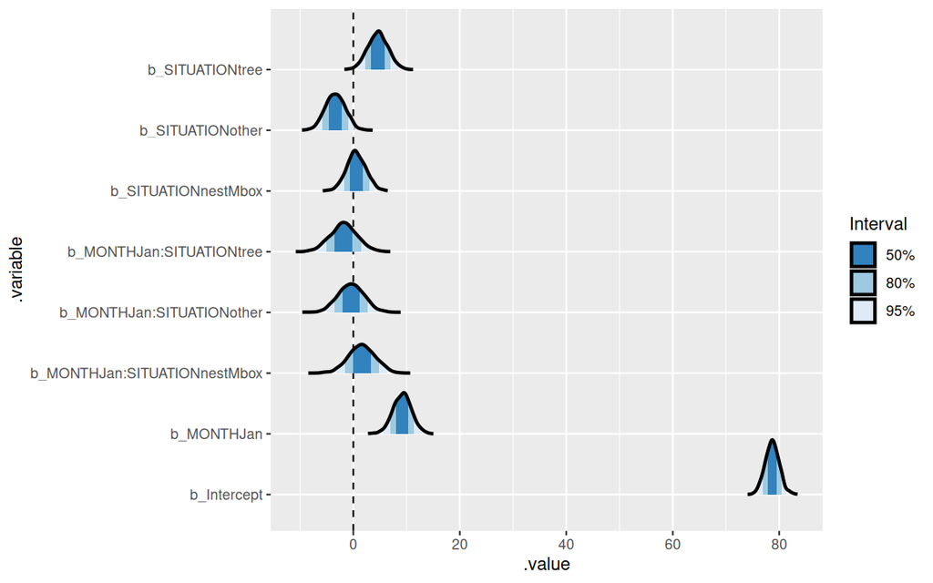

```r
starling_brm3 |>
  gather_draws(`b_Intercept.*|b_SITUATION.*|b_MONTH.*`, regex = TRUE) |>
  ggplot() +
  geom_vline(xintercept = 0, linetype = "dashed") +
  stat_slab(aes(
    x = .value, y = .variable,
    fill = stat(ggdist::cut_cdf_qi(cdf,
      .width = c(0.5, 0.8, 0.95),
      labels = scales::percent_format()
    ))
  ), color = "black") +
  scale_fill_brewer("Interval", direction = -1, na.translate = FALSE)
```

[figure not shown]

```r
starling_brm3 |>
  gather_draws(`.Intercept.*|b_SITUATION.*|b_MONTH.*`, regex = TRUE) |>
  ggplot() +
  geom_vline(xintercept = 0, linetype = "dashed") +
  stat_halfeye(aes(x = .value, y = .variable)) +
  theme_classic()
```

**bayesplot**

```
'pars' not specified. Showing first 10 parameters by default.
```

```
ci_level: 0.8 (80% intervals)
```

```
outer_level: 0.95 (95% intervals)
```

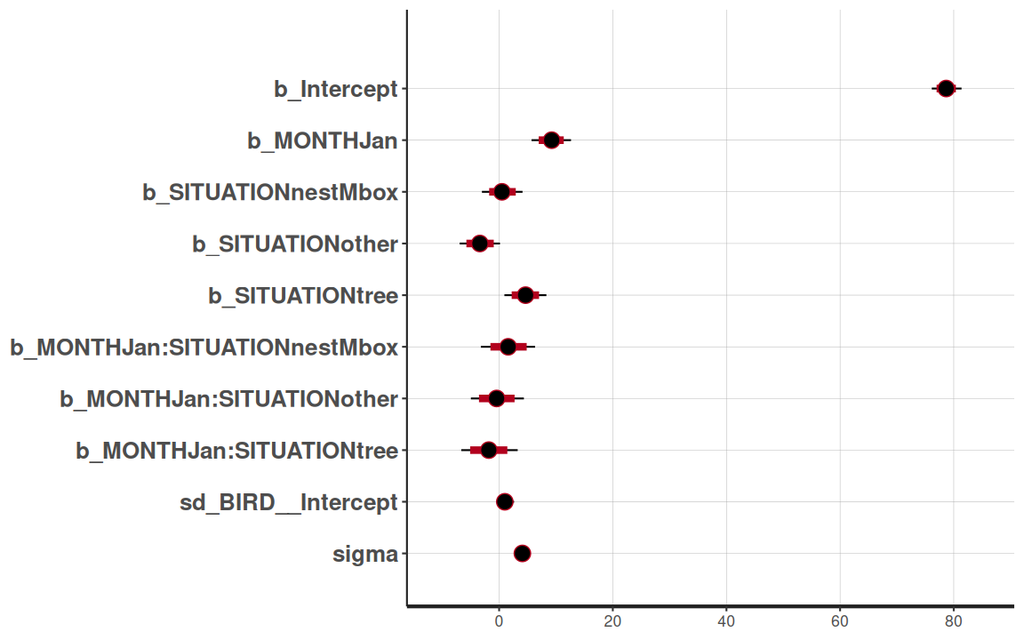

```r
starling_brm3$fit %>% plot(type = "intervals")
```

**half-eye (ggdist)**

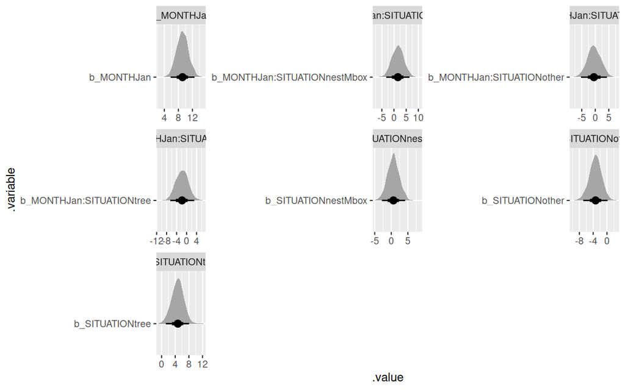

```r
starling_brm4 |>
  gather_draws(`^b_.*`, regex = TRUE) |>
  filter(.variable != "b_Intercept") |>
  ggplot() +
  stat_halfeye(aes(x = .value, y = .variable)) +
  facet_wrap(~.variable, scales = "free")
```

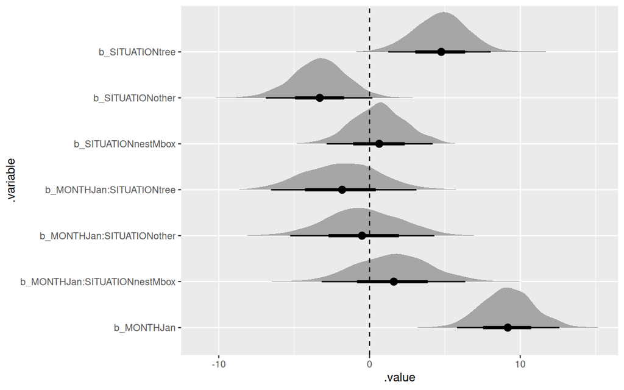

```r
starling_brm4 |>
  gather_draws(`^b_.*`, regex = TRUE) |>
  filter(.variable != "b_Intercept") |>
  ggplot() +
  stat_halfeye(aes(x = .value, y = .variable)) +
  geom_vline(xintercept = 0, linetype = "dashed")
```

**density ridges (ggridges)**

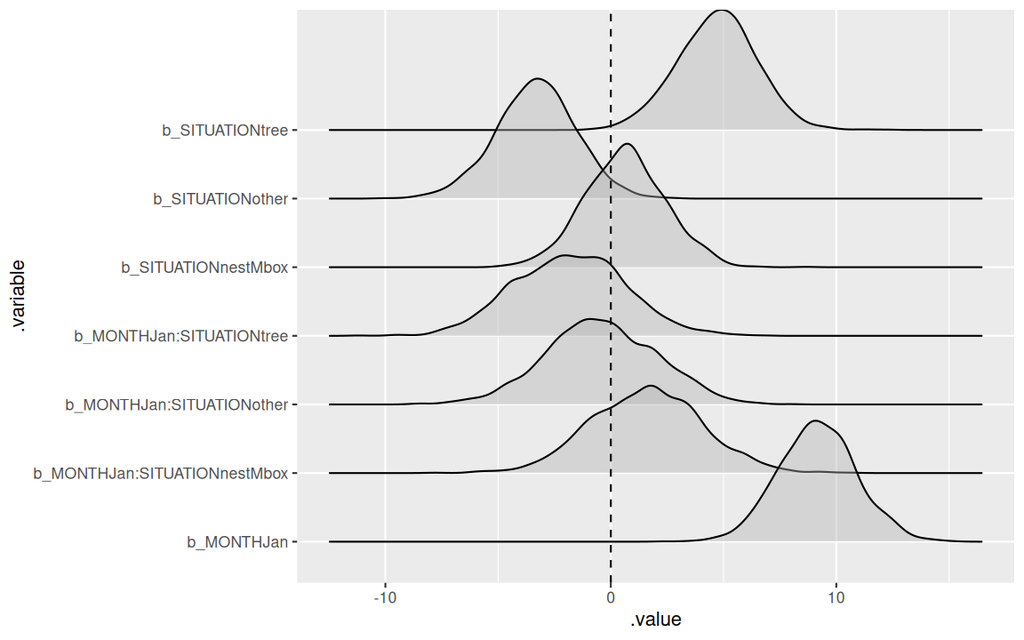

```r
starling_brm4 |>
  gather_draws(`^b_.*`, regex = TRUE) |>
  filter(.variable != "b_Intercept") |>
  ggplot() +
  geom_density_ridges(aes(x = .value, y = .variable), alpha = 0.4) +
  geom_vline(xintercept = 0, linetype = "dashed")
```

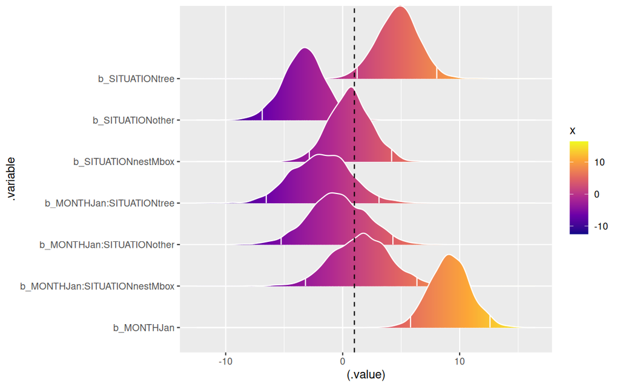

```r
## Or in colour
starling_brm4 |>
  gather_draws(`^b_.*`, regex = TRUE) |>
  filter(.variable != "b_Intercept") |>
  ggplot() +
  geom_density_ridges_gradient(
    aes(
      x = (.value),
      y = .variable,
      fill = stat(x)
    ),
    alpha = 0.4, colour = "white",
    quantile_lines = TRUE,
    quantiles = c(0.025, 0.975)
  ) +
  geom_vline(xintercept = 1, linetype = "dashed") +
  scale_x_continuous() +
  scale_fill_viridis_c(option = "C")
```

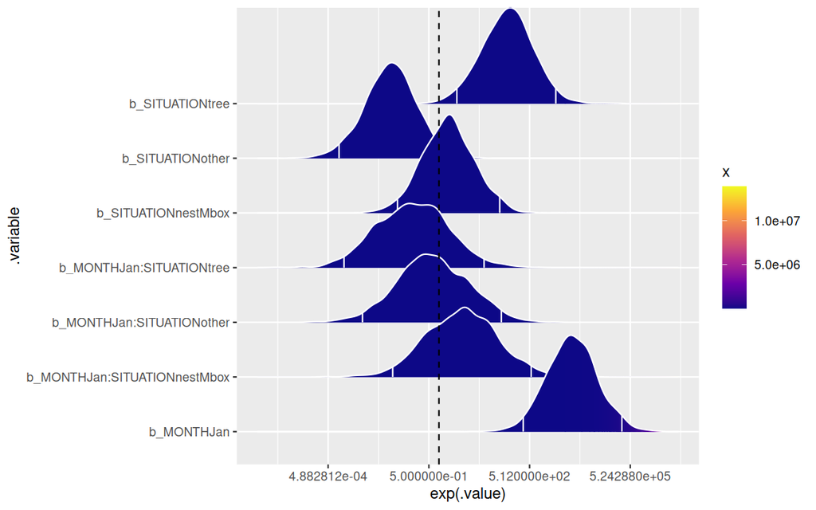

```r
## Fractional scale
starling_brm4 |>
  gather_draws(`^b_.*`, regex = TRUE) |>
  filter(.variable != "b_Intercept") |>
  ggplot() +
  geom_density_ridges_gradient(
    aes(
      x = exp(.value),
      y = .variable,
      fill = stat(x)
    ),
    alpha = 0.4, colour = "white",
    quantile_lines = TRUE,
    quantiles = c(0.025, 0.975)
  ) +
  geom_vline(xintercept = 1, linetype = "dashed") +
  scale_x_continuous(trans = scales::log2_trans()) +
  scale_fill_viridis_c(option = "C")
```

**tidy_draws**

```r
starling_brm4 |> tidy_draws()
```

```
# A tibble: 1,500 × 109
   .chain .iteration .draw b_Intercept b_MONTHJan b_SITUATIONnestMbox
    <int>      <int> <int>       <dbl>      <dbl>               <dbl>
 1      1          1     1        77.4       8.54              3.47
 2      1          2     2        79.2       6.84              0.124
 3      1          3     3        77.9      12.6               2.08
 4      1          4     4        78.7       8.53             -0.576
 5      1          5     5        79.1       8.60             -0.460
 6      1          6     6        78.0      10.6               2.38
 7      1          7     7        79.2      10.8               0.482
 8      1          8     8        81.0       9.14             -4.12
 9      1          9     9        78.3       8.57              0.0517
10      1         10    10        77.3      10.6               0.945
# ℹ 1,490 more rows
# ℹ 103 more variables: b_SITUATIONother <dbl>, b_SITUATIONtree <dbl>,
#   `b_MONTHJan:SITUATIONnestMbox` <dbl>, `b_MONTHJan:SITUATIONother` <dbl>,
#   `b_MONTHJan:SITUATIONtree` <dbl>, sd_BIRD__Intercept <dbl>,
#   sd_BIRD__MONTHJan <dbl>, cor_BIRD__Intercept__MONTHJan <dbl>, sigma <dbl>,
#   Intercept <dbl>, `r_BIRD[inside1,Intercept]` <dbl>,
#   `r_BIRD[inside10,Intercept]` <dbl>, `r_BIRD[inside2,Intercept]` <dbl>, …
```

**spread_draws**

```r
starling_brm4 |> spread_draws(`.*Intercept.*|b_SITUATION.*|b_MONTH.*`, regex = TRUE)
```

```
# A tibble: 1,500 × 55
   .chain .iteration .draw b_Intercept b_MONTHJan b_SITUATIONnestMbox
    <int>      <int> <int>       <dbl>      <dbl>               <dbl>
 1      1          1     1        77.4       8.54              3.47
 2      1          2     2        79.2       6.84              0.124
 3      1          3     3        77.9      12.6               2.08
 4      1          4     4        78.7       8.53             -0.576
 5      1          5     5        79.1       8.60             -0.460
 6      1          6     6        78.0      10.6               2.38
 7      1          7     7        79.2      10.8               0.482
 8      1          8     8        81.0       9.14             -4.12
 9      1          9     9        78.3       8.57              0.0517
10      1         10    10        77.3      10.6               0.945
# ℹ 1,490 more rows
# ℹ 49 more variables: b_SITUATIONother <dbl>, b_SITUATIONtree <dbl>,
#   `b_MONTHJan:SITUATIONnestMbox` <dbl>, `b_MONTHJan:SITUATIONother` <dbl>,
#   `b_MONTHJan:SITUATIONtree` <dbl>, sd_BIRD__Intercept <dbl>,
#   cor_BIRD__Intercept__MONTHJan <dbl>, Intercept <dbl>,
#   `r_BIRD[inside1,Intercept]` <dbl>, `r_BIRD[inside10,Intercept]` <dbl>,
#   `r_BIRD[inside2,Intercept]` <dbl>, `r_BIRD[inside3,Intercept]` <dbl>, …
```

**posterior_samples**

```r
starling_brm4 |>
  posterior_samples() |>
  as_tibble()
```

```
# A tibble: 1,500 × 100
   b_Intercept b_MONTHJan b_SITUATIONnestMbox b_SITUATIONother b_SITUATIONtree
         <dbl>      <dbl>               <dbl>            <dbl>           <dbl>
 1        77.4       8.54              3.47              -1.51            4.89
 2        79.2       6.84              0.124             -3.65            6.02
 3        77.9      12.6               2.08              -3.93            6.63
 4        78.7       8.53             -0.576             -4.39            4.50
 5        79.1       8.60             -0.460             -5.39            4.78
 6        78.0      10.6               2.38              -3.88            6.31
 7        79.2      10.8               0.482             -4.04            5.48
 8        81.0       9.14             -4.12              -6.16            3.49
 9        78.3       8.57              0.0517            -2.55            3.77
10        77.3      10.6               0.945             -2.19            6.04
# ℹ 1,490 more rows
# ℹ 95 more variables: `b_MONTHJan:SITUATIONnestMbox` <dbl>,
#   `b_MONTHJan:SITUATIONother` <dbl>, `b_MONTHJan:SITUATIONtree` <dbl>,
#   sd_BIRD__Intercept <dbl>, sd_BIRD__MONTHJan <dbl>,
#   cor_BIRD__Intercept__MONTHJan <dbl>, sigma <dbl>, Intercept <dbl>,
#   `r_BIRD[inside1,Intercept]` <dbl>, `r_BIRD[inside10,Intercept]` <dbl>,
#   `r_BIRD[inside2,Intercept]` <dbl>, `r_BIRD[inside3,Intercept]` <dbl>, …
```

**\(R^2\)**

```r
starling_brm4 |>
  bayes_R2(re.form = NA, summary = FALSE) |>
  median_hdci()
```

```
          y      ymin      ymax .width .point .interval
1 0.6266656 0.5319229 0.6927965   0.95 median      hdci
```

```r
starling_brm4 |>
  bayes_R2(re.form = ~ (1 | BIRD), summary = FALSE) |>
  median_hdci()
```

```
          y      ymin      ymax .width .point .interval
1 0.6483664 0.5405546 0.7276725   0.95 median      hdci
```

```r
starling_brm4 |>
  bayes_R2(re.form = ~ (MONTH | BIRD), summary = FALSE) |>
  median_hdci()
```

```
          y      ymin      ymax .width .point .interval
1 0.6958443 0.5594972 0.8373179   0.95 median      hdci
```

```r
starling_brm4 |>
  bayes_R2(re.form = ~ (MONTH + MONTH:SITUATION | BIRD), summary = FALSE) |>
  median_hdci()
```

```
          y      ymin      ymax .width .point .interval
1 0.6266656 0.5319229 0.6927965   0.95 median      hdci
```

```r
starling_brm4 |>
  bayes_R2(re.form = ~ (MONTH * SITUATION | BIRD), summary = FALSE) |>
  median_hdci()
```

```
          y      ymin      ymax .width .point .interval
1 0.6266656 0.5319229 0.6927965   0.95 median      hdci
```

**Modelsummary**

```r
starling_brm4 |> modelsummary(
  statistic = c("conf.low", "conf.high"),
  shape = term ~ statistic,
  exponentiate = FALSE
)
```

|  | (1) Est. | (1) 2.5 % | (1) 97.5 % |
| --- | --- | --- | --- |
| b_Intercept | 78.575 | 76.168 | 81.033 |
| b_MONTHJan | 9.169 | 5.802 | 12.592 |
| b_SITUATIONnestMbox | 0.641 | -2.853 | 4.184 |
| b_SITUATIONother | -3.306 | -6.876 | 0.183 |
| b_SITUATIONtree | 4.758 | 1.236 | 8.043 |
| b_MONTHJan × SITUATIONnestMbox | 1.609 | -3.182 | 6.348 |
| b_MONTHJan × SITUATIONother | -0.502 | -5.262 | 4.295 |
| b_MONTHJan × SITUATIONtree | -1.819 | -6.534 | 3.108 |
| sd_BIRD__Intercept | 1.024 | 0.065 | 2.992 |
| sd_BIRD__MONTHJan | 2.062 | 0.105 | 5.025 |
| cor_BIRD__Intercept__MONTHJan | -0.160 | -0.943 | 0.914 |
| sigma | 3.812 | 2.597 | 4.701 |
| Num.Obs. | 80 |  |  |
| R2 | 0.696 |  |  |
| R2 Adj. | 0.587 |  |  |
| R2 Marg. | 0.627 |  |  |
| ELPD | -232.0 |  |  |
| ELPD s.e. | 5.0 |  |  |
| LOOIC | 464.1 |  |  |
| LOOIC s.e. | 10.1 |  |  |
| WAIC | 461.4 |  |  |
| RMSE | 3.17 |  |  |
| r2.adjusted.marginal | 0.409469102360111 |  |  |

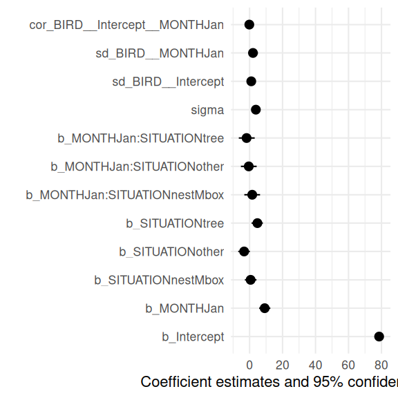

```r
starling_brm4 |> modelplot(exponentiate = FALSE)
```

# 10 Further investigations

**brms**

```
NOTE: Results may be misleading due to involvement in interactions
```

[output not shown]

```
NOTE: Results may be misleading due to involvement in interactions
```

```
 contrast  estimate lower.HPD upper.HPD
 Nov - Jan    -9.01     -10.8     -7.05

Results are averaged over the levels of: SITUATION
Point estimate displayed: median
HPD interval probability: 0.95
```

```
SITUATION = inside:
 contrast  estimate lower.HPD upper.HPD
 Nov - Jan    -9.17     -12.7     -5.98

SITUATION = nest-box:
 contrast  estimate lower.HPD upper.HPD
 Nov - Jan   -10.71     -14.3     -7.29

SITUATION = other:
 contrast  estimate lower.HPD upper.HPD
 Nov - Jan    -8.80     -12.2     -4.98

SITUATION = tree:
 contrast  estimate lower.HPD upper.HPD
 Nov - Jan    -7.35     -11.1     -4.02

Point estimate displayed: median
HPD interval probability: 0.95
```

```
# A tibble: 4 × 8
  contrast SITUATION .value .lower .upper .width .point .interval
  <chr>    <fct>      <dbl>  <dbl>  <dbl>  <dbl> <chr>  <chr>
1 Jan/Nov  inside     11.6    7.24   16.2   0.95 median hdci
2 Jan/Nov  nest-box   13.5    9.17   18.4   0.95 median hdci
3 Jan/Nov  other      11.7    6.34   16.5   0.95 median hdci
4 Jan/Nov  tree        8.84   4.60   13.6   0.95 median hdci
```

```
# A tibble: 6 × 8
# Groups:   SITUATION [1]
  SITUATION .chain .iteration .draw   Nov   Jan   Eff  PEff
  <fct>      <int>      <int> <int> <dbl> <dbl> <dbl> <dbl>
1 inside        NA         NA     1  77.4  85.9  8.54 11.0
2 inside        NA         NA     2  79.2  86.0  6.84  8.63
3 inside        NA         NA     3  77.9  90.5 12.6  16.2
4 inside        NA         NA     4  78.7  87.3  8.53 10.8
5 inside        NA         NA     5  79.1  87.7  8.60 10.9
6 inside        NA         NA     6  78.0  88.5 10.6  13.5
```

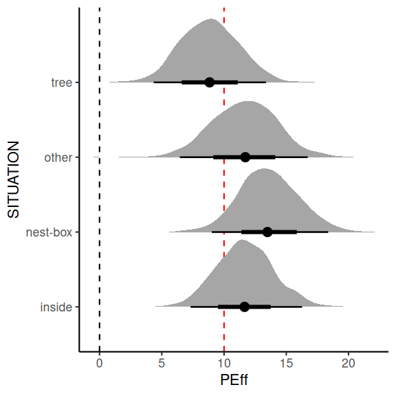

```
# A tibble: 4 × 7
  SITUATION  PEff .lower .upper .width .point .interval
  <fct>     <dbl>  <dbl>  <dbl>  <dbl> <chr>  <chr>
1 inside    11.6    7.24   16.2   0.95 median hdci
2 nest-box  13.5    9.17   18.4   0.95 median hdci
3 other     11.7    6.34   16.5   0.95 median hdci
4 tree       8.84   4.60   13.6   0.95 median hdci
```

```
# A tibble: 4 × 3
  SITUATION  Prob `Prob>10`
  <fct>     <dbl>     <dbl>
1 inside    1         0.763
2 nest-box  1         0.941
3 other     0.999     0.728
4 tree      1         0.304
```

```r
starling_brm4 |>
  emmeans(~SITUATION) |>
  pairs()
```

Compare specific sets of SITUATION within each MONTH

```r
levels(starling$SITUATION)
```

```
[1] "inside"   "nest-box" "other"    "tree"
```

```
NOTE: Results may be misleading due to involvement in interactions
```

```
 contrast               estimate lower.HPD upper.HPD
 SITUATION.Nat vs Art       4.53     2.376      7.00
 SITUATION.Tree vs I/NB     3.13     0.739      5.57
 SITUATION.Tree vs NB       2.36    -0.362      5.17

Results are averaged over the levels of: MONTH
Point estimate displayed: median
HPD interval probability: 0.95
```

```
NOTE: Results may be misleading due to involvement in interactions
```

```
# A tibble: 4,500 × 5
# Groups:   contrast [3]
   contrast             .chain .iteration .draw .value
   <chr>                 <int>      <int> <int>  <dbl>
 1 SITUATION.Nat vs Art     NA         NA     1   3.03
 2 SITUATION.Nat vs Art     NA         NA     2   6.46
 3 SITUATION.Nat vs Art     NA         NA     3   5.83
 4 SITUATION.Nat vs Art     NA         NA     4   5.25
 5 SITUATION.Nat vs Art     NA         NA     5   4.98
 6 SITUATION.Nat vs Art     NA         NA     6   3.42
 7 SITUATION.Nat vs Art     NA         NA     7   5.14
 8 SITUATION.Nat vs Art     NA         NA     8   4.35
 9 SITUATION.Nat vs Art     NA         NA     9   4.98
10 SITUATION.Nat vs Art     NA         NA    10   4.34
# ℹ 4,490 more rows
```

```
MONTH = Nov:
 contrast               estimate lower.HPD upper.HPD
 SITUATION.Nat vs Art       5.63    2.7219      8.38
 SITUATION.Tree vs I/NB     4.41    1.4919      7.48
 SITUATION.Tree vs NB       4.10    0.7234      7.78

MONTH = Jan:
 contrast               estimate lower.HPD upper.HPD
 SITUATION.Nat vs Art       3.39    0.0497      6.70
 SITUATION.Tree vs I/NB     1.77   -1.4540      5.36
 SITUATION.Tree vs NB       0.72   -3.4886      4.39

Point estimate displayed: median
HPD interval probability: 0.95
```

```
# A tibble: 6 × 8
# Groups:   contrast [1]
  contrast             .chain .iteration .draw   Nov    Jan   Eff  PEff
  <fct>                 <int>      <int> <int> <dbl>  <dbl> <dbl> <dbl>
1 SITUATION.Nat vs Art     NA         NA     1  4.23 1.82   -2.41 -57.0
2 SITUATION.Nat vs Art     NA         NA     2  7.20 5.72   -1.48 -20.5
3 SITUATION.Nat vs Art     NA         NA     3  7.25 4.41   -2.84 -39.1
4 SITUATION.Nat vs Art     NA         NA     4  6.15 4.35   -1.80 -29.3
5 SITUATION.Nat vs Art     NA         NA     5  6.73 3.23   -3.50 -52.0
6 SITUATION.Nat vs Art     NA         NA     6  6.81 0.0327 -6.78 -99.5
```

# 11 References